# SVM project

MGMT6770

FALL 2019

# 1 Introduction

This is an implementation of a support vector machine designed to identify short-term stock price changes, based on previous stock parameters: open, low, high, close, volume

## 1.1 Stock selected for this exercise:

## 1.2 get data:

names of variables in Disney data price.open price.high price.low price.close volume price.adjusted ret.adjusted.prices ret.closing.prices avgChange Change

```r
DisneyData = read.csv('Forcast1.csv')
names(DisneyData)=c('no','price.open','price.high', 'price.low','price.close','volume', 'price.adjusted','ref.date','ticker','  ret.adjusted.prices','ret.closing.prices','avg','y')

attach(DisneyData)
# set up data frame
DisneyDataFrame = data.frame(open=price.open, high=price.high,
        low=price.low, close=price.close,volume= volume/10000, avg=avg, y= y)
head(DisneyDataFrame)
```

```
##     open   high    low  close  volume           avg y
## 1 100.92 101.53 100.32 101.37  811.68  0.0021739210 E
## 2 100.78 101.65 100.41 100.80  630.50  0.0039833510 E
## 3 101.42 101.51  99.68 100.39  733.78 -0.0002190920 E
## 4 101.00 101.52 100.16 100.35  632.46 -0.0033307670 E
## 5 100.69 101.00  99.73 100.24 1032.80  0.0000368102 E
## 6 101.20 102.59 100.75 102.17  957.74  0.0011130450 E
```

```r
remove(DisneyData)
```

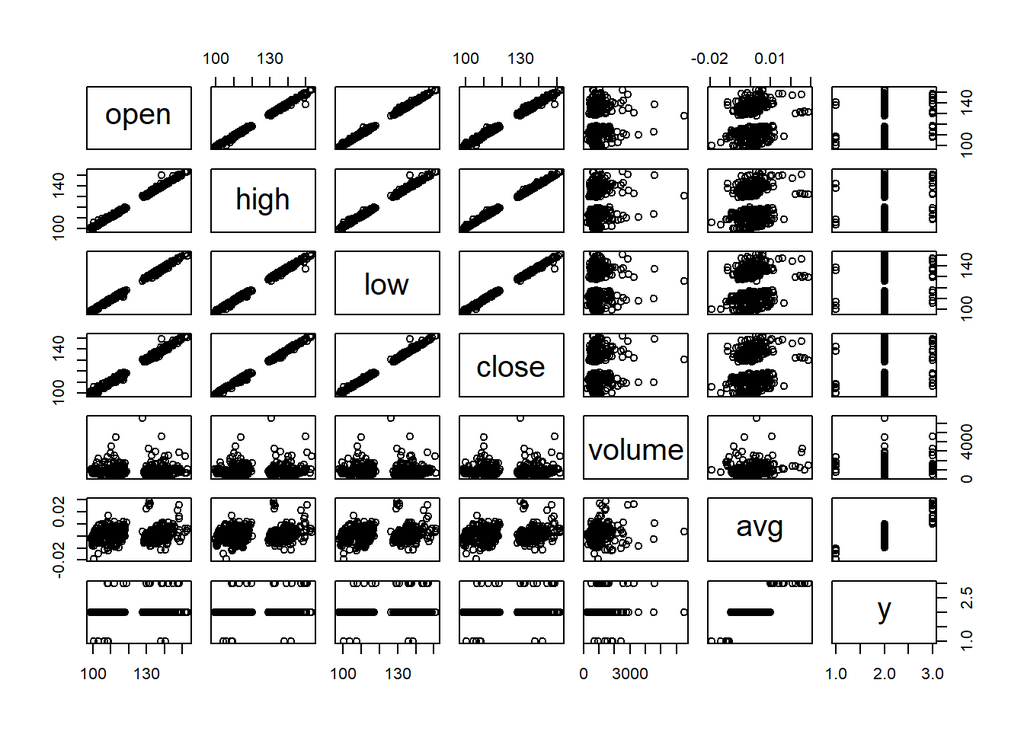

```r
plot(DisneyDataFrame)
```

## 1.3 classification model, categorical response

### 1.3.1 traditional interface:

```r
#x <- subset(DisneyDataFrame, select = 12)
x = select(DisneyDataFrame,avg)
y <- DisneyDataFrame$y
model1 <- svm(x, y)

print(model1)
```

```
##
## Call:
## svm.default(x = x, y = y)
##
##
## Parameters:
##    SVM-Type:  C-classification
##  SVM-Kernel:  radial
##        cost:  1
##
## Number of Support Vectors:  41
```

```r
summary(model1)
```

```
##
## Call:
## svm.default(x = x, y = y)
##
##
## Parameters:
##    SVM-Type:  C-classification
##  SVM-Kernel:  radial
##        cost:  1
##
## Number of Support Vectors:  41
##
##  ( 22 12 7 )
##
##
## Number of Classes:  3
##
## Levels:
##  D E U
```

## 1.4 how well did the model fit?

```r
pred <- predict(model1, x)

# Check accuracy:
table(pred, y)
```

```
##     y
## pred   D   E   U
##    D   6   0   0
##    E   1 393   1
##    U   0   0  18
```

## 1.5 decision values

```r
# compute decision values and probabilities:
pred <- predict(model1, x, decision.values = TRUE)
attr(pred, "decision.values")[1:6,]
```

```
##        E/U      E/D         U/D
## 1 1.316838 1.000866  0.33300144
## 2 1.645563 1.010031  0.46181433
## 3 1.045399 1.087509  0.21006537
## 4 1.010085 1.515505 -0.01948482
## 5 1.061217 1.068883  0.22292324
## 6 1.161986 1.017956  0.27575248
```

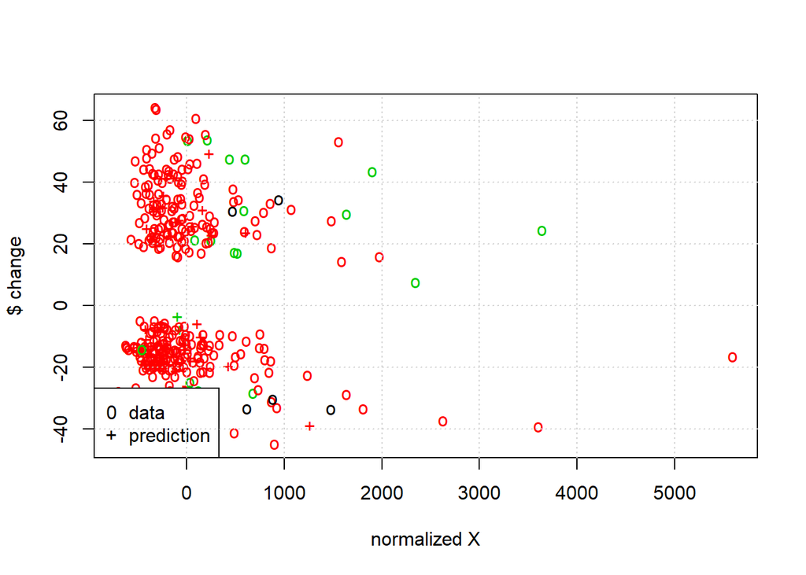

```r
# visualize (classes by color, SV by crosses):
plot(cmdscale(dist(DisneyDataFrame[,-7])),
     col = as.integer(DisneyDataFrame[,7]),xlab="normalized X", ylab = "$ change",
     pch = c("o","+")[1:150 %in% model1$index + 1])
legend('bottomleft',c('data','prediction'),pch=c('0','+'))
grid()
```

# 2 train and test set:

```r
pctTrain=0.70
nObs = length(x[,1])
nTrain = round(pctTrain*nObs,0)
TrainSetIndex = 1:nTrain

# or ?
#TrainSetIndex = sample(1:nObs, nTrain)
```

## 2.1 set up training set, test set

```r
# first the training set

XtrainSet = DisneyDataFrame[TrainSetIndex,-7]
YtrainSet = DisneyDataFrame$change[TrainSetIndex]
```

## 2.2 get the model from training set..

```r
model2 <- svm(XtrainSet, YtrainSet)

print(model2)
```

```
##
## Call:
## svm.default(x = XtrainSet, y = YtrainSet)
##
##
## Parameters:
##    SVM-Type:  one-classification
##  SVM-Kernel:  radial
##       gamma:  0.1666667
##          nu:  0.5
##
## Number of Support Vectors:  148
```

```r
summary(model2)
```

```
##
## Call:
## svm.default(x = XtrainSet, y = YtrainSet)
##
##
## Parameters:
##    SVM-Type:  one-classification
##  SVM-Kernel:  radial
##       gamma:  0.1666667
##          nu:  0.5
##
## Number of Support Vectors:  148
##
##
##
##
## Number of Classes: 1
```

## 2.3 now the test set..

```r
XtestSet = DisneyDataFrame[(nTrain:nObs),-7]
YtestSet = DisneyDataFrame$avg[nTrain:nObs]
```

## 2.4 and evaluate with the test data

```r
pred2 <- predict(model2, XtestSet)
# And the accuracy..

table(pred2, YtestSet)
```

[output not shown]

[output cut: 23 more lines]

[output not shown]

## 2.5 tune

```r
#use optimized parameters...
model3 <- svm(XtrainSet, YtrainSet, gamma=0.5, cost=4 )

print(model3)
```

```
##
## Call:
## svm.default(x = XtrainSet, y = YtrainSet, gamma = 0.5, cost = 4)
##
##
## Parameters:
##    SVM-Type:  one-classification
##  SVM-Kernel:  radial
##       gamma:  0.5
##          nu:  0.5
##
## Number of Support Vectors:  151
```

```r
summary(model3)
```

```
##
## Call:
## svm.default(x = XtrainSet, y = YtrainSet, gamma = 0.5, cost = 4)
##
##
## Parameters:
##    SVM-Type:  one-classification
##  SVM-Kernel:  radial
##       gamma:  0.5
##          nu:  0.5
##
## Number of Support Vectors:  151
##
##
##
##
## Number of Classes: 1
```

```r
pred3 <- predict(model3, XtestSet)
# And the accuracy..

table(pred3, YtestSet)
```

[output not shown]

[output cut: 23 more lines]

[output not shown]

# 3 SVM assignment

## 3.1 complete an rmarkdown file on the stock you selected.

You will turn in the URL for your github accout that has the repo for this assignment.

### 3.1.1 Identify the stock you use for this assignment.

Why did you choose this particular stock?

I like Disney and thought it would be an interesting stock to pick.

### 3.1.2 Use this template to get the SVM:

1. Training and Test sets:

```
Ummm I don't remember what we picked.
```

2. How well did the SVM do?

3. Tune the algorithm- i.e. find optimal gamma and cost values.

We were unable to tune the algorithm.

### 3.1.3 Evaluate SVM performance

1. Did you exmine using other than the ‘open’, ‘low’, ‘high’, ‘close’ prices and volume as predictors?

We used avg. No.

2. Use the SVM you developed to predict stock moves on 16 - 20 Sept. 2019. Compute the ROI assuming the SVM identifies an opportunity, (for example use around $1000 on each of the SVM predictions) Due to when I ran the predictions this time frame is included already.
3. Would you put your own $$ in this SVM?

```
No because I'm a broke college student.
```